# Problem set 5 alternate: Global CO<sub>2</sub>

Colleen Cronin

September 24,2023

## Overview

In this exercise, you will explore data compiled by the [World Bank DataBank](https://databank.worldbank.org/home.aspx) that provides information on the emissions of greenhouse gases and the populations of countries around the world.

Please start by knitting this file. You can use the html file that is generated as a handy reference (it’s much easier to read than the markdown file).

I strongly suggest working in an R script file and copying-and-pasting your code into this R Markdown file, where prompted.

## Grading

The points allotted for each question are provided in highlighted red bold text (e.g., [1.0]) within the question itself. When applicable, total points for a question may represent the sum of individually graded components, which are provided in red text (e.g., [1.0]).

Points may be deducted from each question’s total:

- [50% per violation] Use only functions listed in “Functions that you may use in this assignment”;
- [50%] Include only assignments specified in the question;
- [10%] Ensure that all code is properly indented;
- [10%] Ensure that your code follows modern coding conventions (see *Best practices in modern R coding*);
- [10%] Ensure that all code chunks are formatted as `eval = TRUE` (but see below);
- [10%] Ensure that the class of your response is consistent with the wording of the question (e.g., if you are asked to return a “value” or “vector”, ensure that the resultant object is not a data frame).

*Note: The maximum deduction is the total points value for a given question*

Pay careful attention to the format of your code – not following the rules above will cost you lots of little points (and some big ones) that can really add up!

In addition to points allotted per question, you must ensure that your R Markdown document **runs out-of-the-box** [25% off of the total grade] – in other words, the document will knit without error. Some tips for doing so:

- Do not maintain your project folder in a location that is backed up by an online directory (e.g., Dropbox, iCloud).
- Ensure that all file paths are equivalent to those in this document (e.g., in `source()` or `read_csv()`).
- Do not use `setwd()` in your code (**Never** use `setwd()`!)
- If one of your code chunks contains an error, include `eval = FALSE` in the options for that chunk. Otherwise, ensure all of your code chunks options are `eval = TRUE`.
- Prior to submission, clear all objects from your global environment and try to knit your document again.

Click the blue button below to view the functions that you may use in completing this problem set. Make sure that you know what each function does (use `?[function name]` if you do not). Do not use any functions outside of this list!

In this assignment, you may use **only** the following R functions (*Note: If you are unclear on what a given function does, use `?` to view the help file!*):

- base::`<-`
- base::`=`
- base::`!`
- base::`()`
- base::`:`
- base::`as.numeric`
- base::`c`
- base::`library`
- base::`sum`
- dplyr::`filter`
- dplyr::`left_join`
- dplyr::`mutate`
- dplyr::`select`
- dplyr::`semi_join`
- dplyr::`slice_max`
- dplyr::`summarize`
- ggplot2::`aes`
- ggplot2::`element_line`
- ggplot2::`element_rect`
- ggplot2::`facet_wrap`
- ggplot2::`geom_line`
- ggplot2::`geom_point`
- ggplot2::`ggplot`
- ggplot2::`labs`
- ggplot2::`scale_x_continuous`
- ggplot2::`scale_y_continuous`
- ggplot2::`theme`
- magrittr::`%>%`
- readr::`read_csv`
- tidyr::`pivot_longer`

## Getting started

Open R Studio. Remember that it’s best practice to start with a clean R Studio session (i.e., close any script files, remove objects from your global environment, and clear your history).

1. [0.5] Save and knit this document:

- [0.1] Replace my name in the YAML header with yours
- [0.1] Add the current date in the YAML header
- [0.3] Save the *.rmd* as (*but replace my name with yours*): `problem_set_5_alternate_Evans_Brian.rmd`

2. [0.25] Load the tidyverse library:

```r
library(tidyverse)
```

## Read in and tidy the data

I’ve provided three data sets:

- Country-level information: `world_bank_countries.csv`
- Population data, by country, from 1960 through 2020: `API_SP.POP.TOTL_DS2_en_csv_v2_2763937.csv`
- Per capita CO<sub>2</sub> emission data, by country, from 1960 through 2020: `API_EN.ATM.CO2E.PC_DS2_en_csv_v2_2764620.csv`

*Note: The data set `world_bank_countries.csv` has been cleaned for you. The population and CO<sub>2</sub> datasets are in their raw form (including the names).*

The following code reads in `world_bank_countries.csv` and assigns the name `countries` to your global environment.

```r
countries=read_csv("data/raw/world_bank_countries.csv")%>%select(!country_region)
```

3. [1] In the space below, modify the above code such that it follows best management practices in code formatting.

```r
countries <-
  read_csv("data/raw/world_bank_countries.csv") %>%
  select(!country_region)
```

The code below can be used to read in and normalize raw population data from the World Bank:

```r
# Read in population data:

world_pop_raw <-
  read_csv(
    'data/raw/API_SP.POP.TOTL_DS2_en_csv_v2_2763937.csv',
    skip = 3)

# Subset to columns of interest:

world_pop_column_subset <-
  select(
    world_pop_raw,

    # Rename Country Code column to remove space:

    country_code = `Country Code`,

    # Subset to other columns of interest:

    `1960`:`2020`)


# Make the data tidy by pivoting to a long form table:

world_pop_long <-
  pivot_longer(
    world_pop_column_subset,
    names_to = 'year',
    values_to = 'population',
    `1960`:`2020`)

# Finally, convert the year column to numeric:

world_pop <-
  mutate(
    world_pop_long,
    year = as.numeric(year))
```

*Note: Why did I include “skip = 3” as one of my arguments? You might want to look at what happens when you don’t include a skip argument. If this is confusing, please revisit the video lecture and tutorial on reading and writing data.*

*Also note: Back ticks (e.g.,* `1960`*) are needed when columns start with a number or contain a space.*

4. [1] The code above successfully reads in and wrangles the population data, but not parsimoniously. In the space below, please modify the above code chunk such that the process below is completed in a single, chained analysis and globally assign the name `world_pop` to the resultant object.

```r
world_pop <-
  read_csv(
    'data/raw/API_SP.POP.TOTL_DS2_en_csv_v2_2763937.csv',
    skip = 3) %>%
  select(
    country_code = `Country Code`,
    `1960`:`2020`) %>%
   pivot_longer(
    names_to = 'year',
    values_to = 'population',
    `1960`:`2020`) %>%
   mutate(
    year = as.numeric(year))
```

*Note: Your output should be equivalent to the `world_pop` data frame generated in the preceding example.*

5. [1] The structure of the World Bank CO<sub>2</sub> data is the same as their population data. In a single chained analysis:

- [0.3] Read in the CO<sub>2</sub> data (`API_EN.ATM.CO2E.PC_DS2_en_csv_v2_2764620.csv`)
- [0.3] Wrangle the data such that the resultant tibble contains (only) the variables `country_code`, `year`, and `co2`
- [0.3] Convert the class of the year variable to numeric
- [0.1] Globally assign the name `co2` to the resultant object

```r
co2 <-
  read_csv(
    'data/raw/API_EN.ATM.CO2E.PC_DS2_en_csv_v2_2764620.csv',
    skip = 3) %>%
  select(
    country_code = `Country Code`,
    `1960`:`2020`) %>%
   pivot_longer(
    names_to = 'year',
    values_to = 'co2',
    `1960`:`2020`) %>%
   mutate(
    year = as.numeric(year))
```

Recall the tidy rule that every level of observation forms a table. The population table and the CO<sub>2</sub> table are the same level of observation – each characterize some attribute of the country on a given year. As such, the data should be stored in the same table. To adhere to the tidy data rules, we’ll need to join the tables together.

6. [1.5] Join the `world_pop` and `co2` tibbles [1.25] and globally assign the name `population_co2` to the resultant object [0.1].

*Hint: You’ll have to be careful here, because the two tibbles contain two common columns that define each observation! This is what is known as a **compound key**. See `?join` for how to address this.*

```r
population_co2 <-
  world_pop %>%
  left_join(
    co2,
    by = c("country_code", "year"))
```

Remove `world_pop` and `co2` from your global environment [0.15]:

```r
rm(world_pop)

rm(co2)
```

## Data output

Our final goal will be to visualize the change in per capita CO<sub>2</sub> emissions from 1960-2018 for the countries that emitted the most total CO<sub>2</sub> across years. The CO<sub>2</sub> data are provided in per capita emissions (units: metric tons of CO<sub>2</sub> per person). To calculate the total annual CO<sub>2</sub> submissions per year, we could use:

```r
population_co2 %>%
  mutate(total_co2 = population*co2)
```

7. [1.75] Generate a data frame of the total emissions from the 5 countries that have emitted the most CO<sub>2</sub> *across* years and globally assign the name `total_emission` to the resultant object ([0.1]). In doing so, ensure that the data:

- [0.5] Include a variable that represents the total CO<sub>2</sub> emissions for each country
- [0.5] Contain **only** countries with records in the `countries` data frame
- [0.5] Are subset to the five countries with the highest total CO<sub>2</sub> emissions (and also satisfy the condition above)
- [0.15] Contain **only** the fields `country_code` and `total_co2`

```r
total_emission <-
  population_co2 %>%
  mutate(total_co2 = population*co2) %>%
  filter(country_code %in% countries$country_code) %>%
  summarize(total_co2 =
              sum(total_co2, na.rm = TRUE),
            .by = "country_code") %>%
  select(country_code, total_co2) %>%
  slice_max(total_co2, n = 5)
```

8. [3] Using `big_emitters` and `population_co2`, generate a ggplot that shows the **per capita** CO<sub>2</sub> emissions from 1960 to 2018 for the five countries with the highest **total** CO<sub>2</sub> emissions. Plot the data such that:

- [0.3] The data being plotted are the per capita emissions from 1960-2018 for the five countries with highest total emissions in 2018
- [0.3] Your x-aesthetic is year and is labeled “Year”
- [0.3] Your y-aesthetic is co_2 and is labeled “Carbon dioxide emissions (metric tons/person)”
- [0.3] Your color aesthetic is country_name and is labeled “Country” (*Hint: It’s often easier to modify the data going into a `ggplot` than inside of a `ggplot` function*)
- [0.3] Your plot includes point and line geometries
- [0.3] The x-axis ranges from 1960 to 2020
- [0.3] The y-axis ranges from 0 to 30
- [0.3] The plot includes a descriptive title
- [0.3] The background of the plot is white and contains no grid lines
- [0.3] The axis lines are black

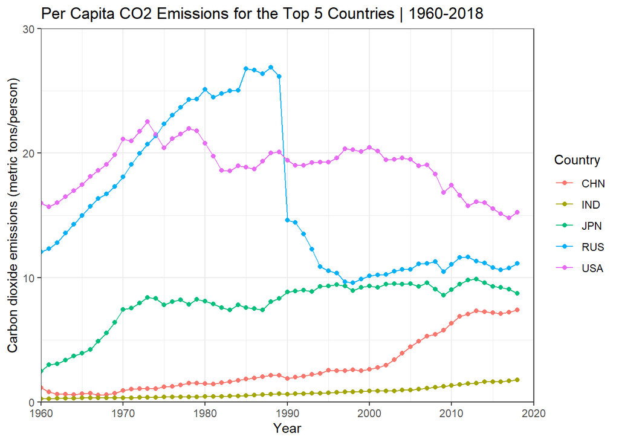

```r
population_co2 %>%
  filter(country_code %in% total_emission$country_code,
         year %in% c(1960:2018)) %>%
  select("Country" = country_code,
         everything()) %>%
ggplot(
  aes(x = year,
      y = co2,
      color = Country)) +
  geom_point() +
  geom_line() +
  scale_y_continuous(
    limits = c(0, 30),
    expand = c(0,0)) +
  scale_x_continuous(
    limits = c(1960, 2020),
    expand = c(0, 0)) +
  labs(
    title = 'Per Capita CO2 Emissions for the Top 5 Countries | 1960-2018',
    x = 'Year',
    y = 'Carbon dioxide emissions (metric tons/person)') +
  theme_bw()
```

## Submission

Please save your R markdown (.Rmd) and submit (only) your R markdown (.Rmd) file to Blackboard. *Do not submit the html file!*.